# NMZL

Wei Zhang

1/3/2021

Download the fastq files from GEO.

Use fastqc to check the quality of the fastq files

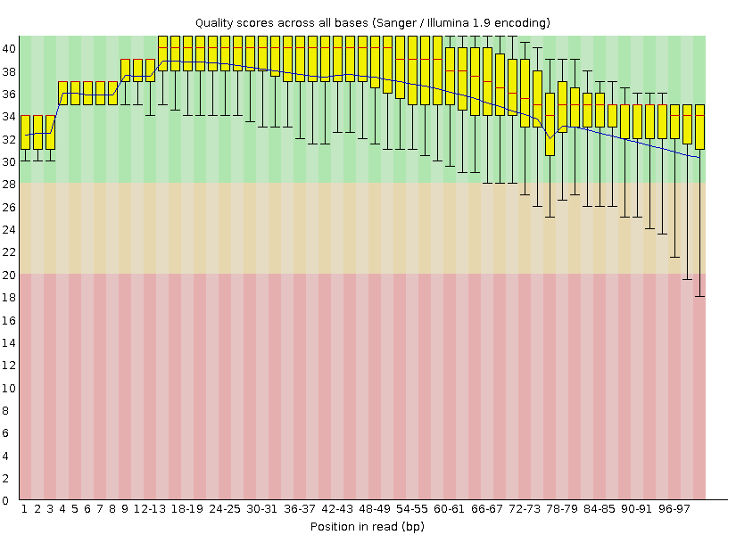

Per base sequence quality for Tumor1_1.fastq.gz

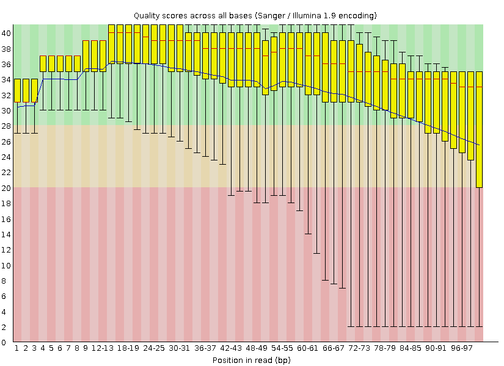

Mapping the fastq data to the reference: will create a SAM file.

-R ‘@RG’ info (especially the SM/sample info) is required for the GATK to call somatic variations (against the germline)

Use samtools to convert to bam and sort

The paramiter "-q 20“ will filter out the reads with quality score lower than 20.

Use picard tool to mark duplicates in the sorted bam file

The mapping algorithms that are used in the initial step of aligning the data to the reference are prone to various types of artifacts.The GATK programe can identifies intervals that need to be realigned, and can determine the optimal consensus sequence and performs the actual realignment of reads.

This step will create a list of intervals that need realignment. The argument “-L chromosome:BP-range” can be used to set the target region of the genome.

This step will perform realignment of the intervals from the last step.

Base quality score re-calibration (BQSR)

The per base quality score is critical for the variant calling algorithms. The estimates of the sequencing machines are often inaccurate. This step generates a GATKReport file “recal_Tumor1.grp” contain the covariation data will be used for re-calibration of the base qualities.

This step generates a “recal_reads.bam” file which contains all the original reads but with the re-calibrated quality scores. The original quality scores are discarded.